# DATA624 HW4

Data Pre-processing

Betsy Rosalen

3/1/2020

## Exercise 3.1

3.1. The UC Irvine Machine Learning Repository[^1] contains a data set related to glass identification. The data consist of 214 glass samples labeled as one of seven class categories. There are nine predictors, including the refractive index and percentages of eight elements: Na, Mg, Al, Si, K, Ca, Ba, and Fe.

The data can be accessed via:

```r
library(mlbench)
data(Glass)
str(Glass)
```

```
## 'data.frame':    214 obs. of  10 variables:
##  $ RI  : num  1.52 1.52 1.52 1.52 1.52 ...
##  $ Na  : num  13.6 13.9 13.5 13.2 13.3 ...
##  $ Mg  : num  4.49 3.6 3.55 3.69 3.62 3.61 3.6 3.61 3.58 3.6 ...
##  $ Al  : num  1.1 1.36 1.54 1.29 1.24 1.62 1.14 1.05 1.37 1.36 ...
##  $ Si  : num  71.8 72.7 73 72.6 73.1 ...
##  $ K   : num  0.06 0.48 0.39 0.57 0.55 0.64 0.58 0.57 0.56 0.57 ...
##  $ Ca  : num  8.75 7.83 7.78 8.22 8.07 8.07 8.17 8.24 8.3 8.4 ...
##  $ Ba  : num  0 0 0 0 0 0 0 0 0 0 ...
##  $ Fe  : num  0 0 0 0 0 0.26 0 0 0 0.11 ...
##  $ Type: Factor w/ 6 levels "1","2","3","5",..: 1 1 1 1 1 1 1 1 1 1 ...
```

### (a) Using visualizations, explore the predictor variables to understand their distributions as well as the relationships between predictors.

```r
kable(summary(Glass[,1:5]))%>%
  kable_styling(bootstrap_options = c("striped", "hover", "condensed", "responsive"))
```

|  | RI | Na | Mg | Al | Si |
| --- | --- | --- | --- | --- | --- |
|  | Min. :1.511 | Min. :10.73 | Min. :0.000 | Min. :0.290 | Min. :69.81 |
|  | 1st Qu.:1.517 | 1st Qu.:12.91 | 1st Qu.:2.115 | 1st Qu.:1.190 | 1st Qu.:72.28 |
|  | Median :1.518 | Median :13.30 | Median :3.480 | Median :1.360 | Median :72.79 |
|  | Mean :1.518 | Mean :13.41 | Mean :2.685 | Mean :1.445 | Mean :72.65 |
|  | 3rd Qu.:1.519 | 3rd Qu.:13.82 | 3rd Qu.:3.600 | 3rd Qu.:1.630 | 3rd Qu.:73.09 |
|  | Max. :1.534 | Max. :17.38 | Max. :4.490 | Max. :3.500 | Max. :75.41 |

```r
kable(summary(Glass[,6:10]))%>%
  kable_styling(bootstrap_options = c("striped", "hover", "condensed", "responsive"))
```

|  | K | Ca | Ba | Fe | Type |
| --- | --- | --- | --- | --- | --- |
|  | Min. :0.0000 | Min. : 5.430 | Min. :0.000 | Min. :0.00000 | 1:70 |
|  | 1st Qu.:0.1225 | 1st Qu.: 8.240 | 1st Qu.:0.000 | 1st Qu.:0.00000 | 2:76 |
|  | Median :0.5550 | Median : 8.600 | Median :0.000 | Median :0.00000 | 3:17 |
|  | Mean :0.4971 | Mean : 8.957 | Mean :0.175 | Mean :0.05701 | 5:13 |
|  | 3rd Qu.:0.6100 | 3rd Qu.: 9.172 | 3rd Qu.:0.000 | 3rd Qu.:0.10000 | 6: 9 |
|  | Max. :6.2100 | Max. :16.190 | Max. :3.150 | Max. :0.51000 | 7:29 |

There 9 numerical predictors (`RI`, `Na`, `Mg`, `Al`, `Si`, `K`, `Ca`, `Ba`, and `Fe`) and one categorical target with 6 levels (`Type`). The data set is highly skewed toward categories 1 and 2 with 146 out of 214 observations falling into those two categories alone. `Ba`, and `Fe` have their first quartile value at 0 indicating that they have a lot of zeros in their distributions.

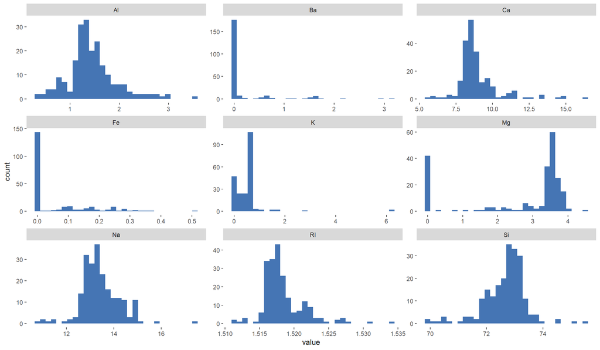

```r
Glass[,1:9] %>%
  gather() %>%
  ggplot(aes(value)) +
    facet_wrap(~ key, scales = "free") +
    geom_histogram(fill = '#4575b4') +
  theme(panel.background = element_blank(), legend.position="top")
```

Histograms of the predictors show that all of them except maybe one, `Si` are moderately to highly skewed. The histogram below has been colored by the target categories and shows that the distributions for different targets values are slightly different (especially for `Al` and `Na`) indicating that those variables may be good predictors.

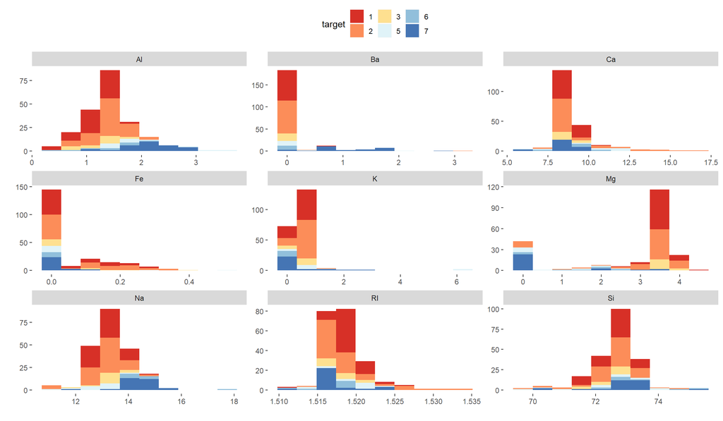

```r
Glass %>%
  gather(-Type, key = "var", value = "val") %>%
  ggplot(aes(x = val, fill=Type)) +
  geom_histogram(bins=10, alpha=1) +
  facet_wrap(~ var, scales = "free") +
  scale_fill_manual("target",
                    values = c('#d73027','#fc8d59','#fee090','#e0f3f8','#91bfdb','#4575b4')) +
  xlab("") +
  ylab("") +
  theme(panel.background = element_blank(), legend.position="top")
```

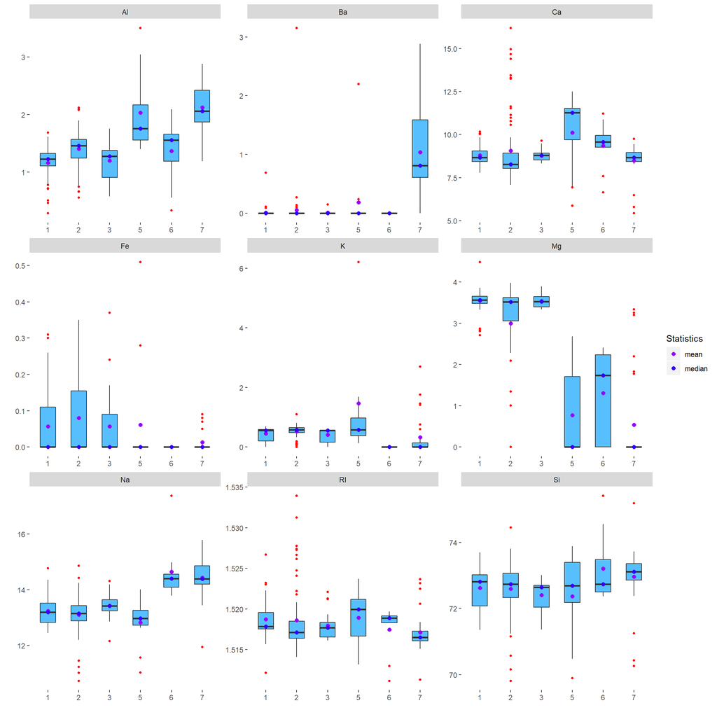

```r
Glass %>%
  gather(-Type,key = "var", value = "val") %>%
  ggplot(aes(x=factor(Type), y=val)) +
  geom_boxplot(width=.5, fill="#58BFFF", outlier.colour="red", outlier.size = 1) +
  stat_summary(aes(colour="mean"), fun.y=mean, geom="point",
               size=2, show.legend=TRUE) +
  stat_summary(aes(colour="median"), fun.y=median, geom="point",
               size=2, show.legend=TRUE) +
  facet_wrap(~ var, scales = "free", ncol=3) +
  labs(colour="Statistics", x="", y="") +
  scale_colour_manual(values=c("#9900FF", "#3300FF")) +
  theme(panel.background=element_blank())
```

Only `RI` and `Ca` seem to be very highly correlated with each other with a correlation of about 0.81.

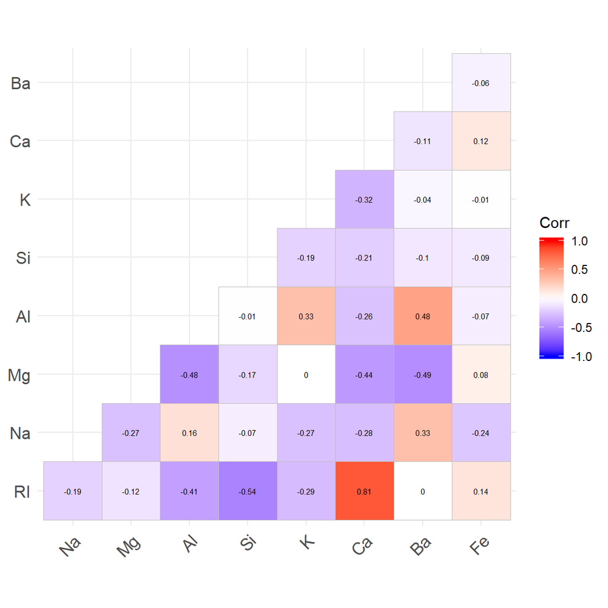

```r
corrs <- round(cor(Glass[,1:9]),3)
ggcorrplot::ggcorrplot(corrs,
       type = 'lower', lab=T, lab_size=2)
```

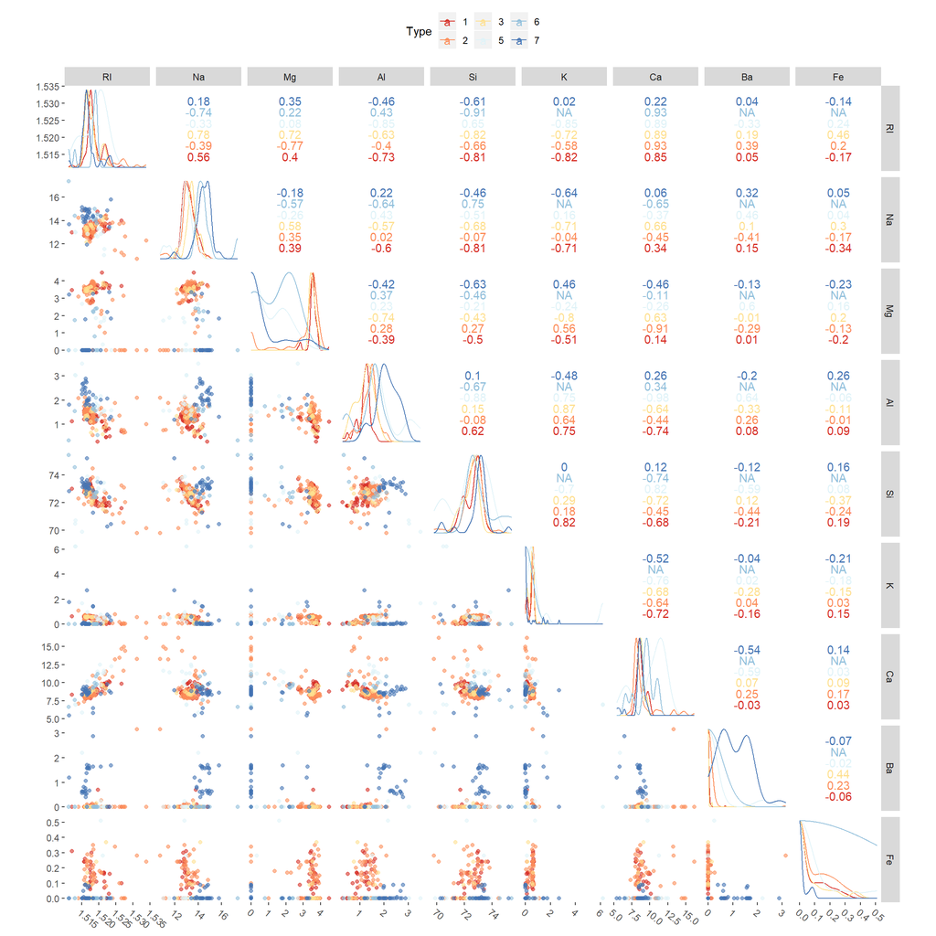

```r
Glass %>%
  ggscatmat(color="Type", alpha=0.6) +
  scale_color_manual(values=c('#d73027','#fc8d59','#fee090','#e0f3f8','#91bfdb','#4575b4')) +
  theme(panel.background=element_blank(), legend.position="top",
        axis.text.x = element_text(angle=-40, vjust=1, hjust=0))
```

```r
highCorr <- findCorrelation(corrs, .75)
highCorr
```

```
## [1] 7
```

The `findCorrelation` function suggests removing column 7 which corresponds to Ca.

There are no missing values in the dataset.

```r
missing <- data.frame(t(apply(is.na(Glass), 2, sum)))
# kable(missing, col.names = "NA's")
row.names(missing) <- c("NA's")
kable(missing) %>%
  kable_styling(bootstrap_options = c("condensed"))
```

|  | RI | Na | Mg | Al | Si | K | Ca | Ba | Fe | Type |
| --- | --- | --- | --- | --- | --- | --- | --- | --- | --- | --- |
| NA’s | 0 | 0 | 0 | 0 | 0 | 0 | 0 | 0 | 0 | 0 |

### (b) Do there appear to be any outliers in the data? Are any predictors skewed?

As noted above most if not all of the predictors have both outliers and skewed distributions as well as a large percentage of zeroes in a few predictors.

### (c) Are there any relevant transformations of one or more predictors that might improve the classification model?

```r
skewness_statistic <- apply(Glass[,1:9], 2, skewness)
ratio_max_to_min <- apply(Glass[,1:9], 2, max)/apply(Glass[,1:9], 2, min)
kable(data.frame(skewness_statistic, ratio_max_to_min)) %>%
  kable_styling(bootstrap_options = c("striped", "hover", "condensed"))
```

|  | skewness_statistic | ratio_max_to_min |
| --- | --- | --- |
| RI | 1.6027151 | 1.015075 |
| Na | 0.4478343 | 1.619758 |
| Mg | -1.1364523 | Inf |
| Al | 0.8946104 | 12.068965 |
| Si | -0.7202392 | 1.080218 |
| K | 6.4600889 | Inf |
| Ca | 2.0184463 | 2.981584 |
| Ba | 3.3686800 | Inf |
| Fe | 1.7298107 | Inf |

Because there are so many zero values in the data it’s hard to estimate the severity of the skew using the max to min ratio since division by zero is undefined. But we clearly have some large skewness values and can clearly see the skew in the histograms.

The skewed distributions might be improved by log, square root, or inverse transformations or a Box-Cox transformation.

Unfortunately because of the zero values `Mg`, `K`, `Ba`, and `Fe` cannot be transformed using Box-Cox. I’m still not sure how to handle that although I found this post by Rob Hyndman on the subject… [Transforming data with zeros](https://robjhyndman.com/hyndsight/transformations/).

```r
# https://stackoverflow.com/questions/46485024/how-to-use-boxcoxtrans-function-in-r
GlassBC <- apply(Glass[,1:9], 2, BoxCoxTrans)
trans_Glass <- purrr::map2(GlassBC, Glass[,1:9], function(x, y) predict(x, y))
trans_Glass_df = as.data.frame(do.call(cbind, trans_Glass))
kable(head(trans_Glass_df)) %>%
  kable_styling(bootstrap_options = c("striped", "hover", "condensed"))
```

| RI | Na | Mg | Al | Si | K | Ca | Ba | Fe |
| --- | --- | --- | --- | --- | --- | --- | --- | --- |
| 0.2838746 | 2.613007 | 4.49 | 0.0976177 | 2575.684 | 0.06 | 0.8254539 | 0 | 0.00 |
| 0.2829051 | 2.631169 | 3.60 | 0.3323808 | 2644.326 | 0.48 | 0.8145827 | 0 | 0.00 |
| 0.2824954 | 2.604909 | 3.55 | 0.4819347 | 2663.270 | 0.39 | 0.8139144 | 0 | 0.00 |
| 0.2829194 | 2.580974 | 3.69 | 0.2715633 | 2635.606 | 0.57 | 0.8195032 | 0 | 0.00 |
| 0.2828507 | 2.585506 | 3.62 | 0.2271057 | 2669.843 | 0.55 | 0.8176698 | 0 | 0.00 |
| 0.2824323 | 2.548664 | 3.61 | 0.5455844 | 2661.810 | 0.64 | 0.8176698 | 0 | 0.26 |

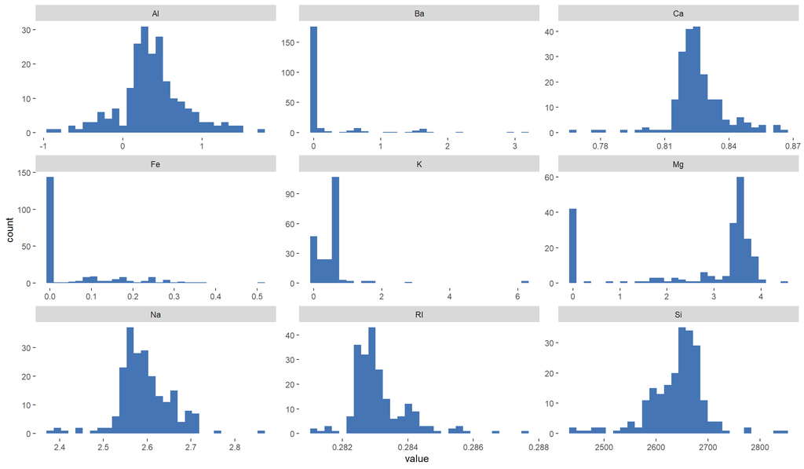

```r
trans_Glass_df %>%
  gather() %>%
  ggplot(aes(value)) +
    facet_wrap(~ key, scales = "free") +
    geom_histogram(fill = '#4575b4') +
  theme(panel.background = element_blank(), legend.position="top")
```

I’m not seeing a lot of improvement in the histograms after transformation with Box-Cox so let’s try something else… Another post suggests three ways of handling the zeros:

> 1. Add a constant value © to each value of variable then take a log transformation
> 2. Impute zero value with mean
> 3. Take square root instead of log for transformation[^2]

Let’s try the square root transformation first.

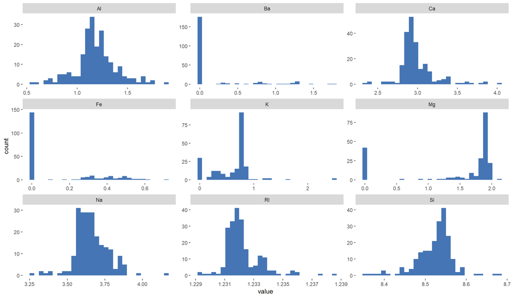

```r
# Square Root transformation
Glass_SqRt <- data.frame(apply(Glass[,1:9], 2, sqrt))

Glass_SqRt %>%
  gather() %>%
  ggplot(aes(value)) +
    facet_wrap(~ key, scales = "free") +
    geom_histogram(fill = '#4575b4') +
  theme(panel.background = element_blank(), legend.position="top")
```

The square root transformation seems to have done a little bit better at taming our distributions, however they are still highly skewed in some cases.

Let’s try one more of the suggestions by using $log(x+1)$ to transform our data.

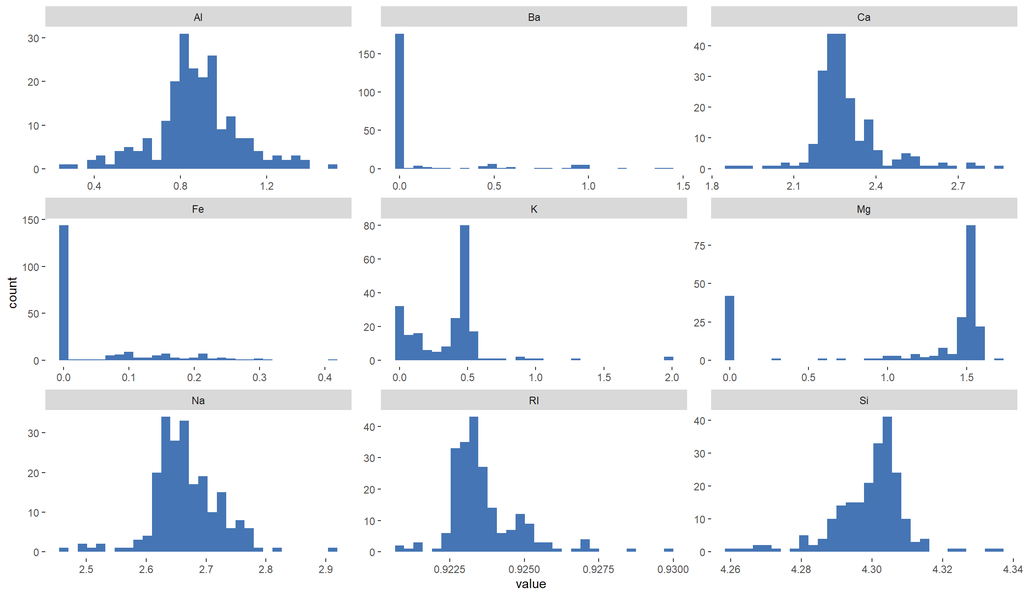

```r
# log(x+1) transformation
Glass_log <- data.frame(apply(Glass[,1:9]+1, 2, log))

Glass_log %>%
  gather() %>%
  ggplot(aes(value)) +
    facet_wrap(~ key, scales = "free") +
    geom_histogram(fill = '#4575b4') +
  theme(panel.background = element_blank(), legend.position="top")
```

Maybe a little better, but still not great!

```r
nearZeroVar(Glass)
```

```
## integer(0)
```

The `caret` function `nearZeroVar` does not indicate that the variabes with high frequenciees of zeroes should be removed so another solution might be to try the alternative Box-Cox transformation that Hyndman suggested in his blog post.[^3]

```r
Alt_BoxCox_Glass <- log1p(Glass[,1:9])
head(Alt_BoxCox_Glass)
```

| RI | Na | Mg | Al | Si | K | Ca | Ba | Fe |
| --- | --- | --- | --- | --- | --- | --- | --- | --- |
| 0.9246596 | 2.683758 | 1.702928 | 0.7419373 | 4.287441 | 0.0582689 | 2.277267 | 0 | 0.0000000 |
| 0.9233100 | 2.700690 | 1.526056 | 0.8586616 | 4.300410 | 0.3920421 | 2.178155 | 0 | 0.0000000 |
| 0.9227419 | 2.676216 | 1.515127 | 0.9321641 | 4.303930 | 0.3293037 | 2.172476 | 0 | 0.0000000 |
| 0.9233299 | 2.653946 | 1.545433 | 0.8285518 | 4.298781 | 0.4510756 | 2.221375 | 0 | 0.0000000 |
| 0.9232346 | 2.658159 | 1.530395 | 0.8064759 | 4.305146 | 0.4382549 | 2.204972 | 0 | 0.0000000 |
| 0.9226544 | 2.623944 | 1.528228 | 0.9631743 | 4.303660 | 0.4946962 | 2.204972 | 0 | 0.2311117 |

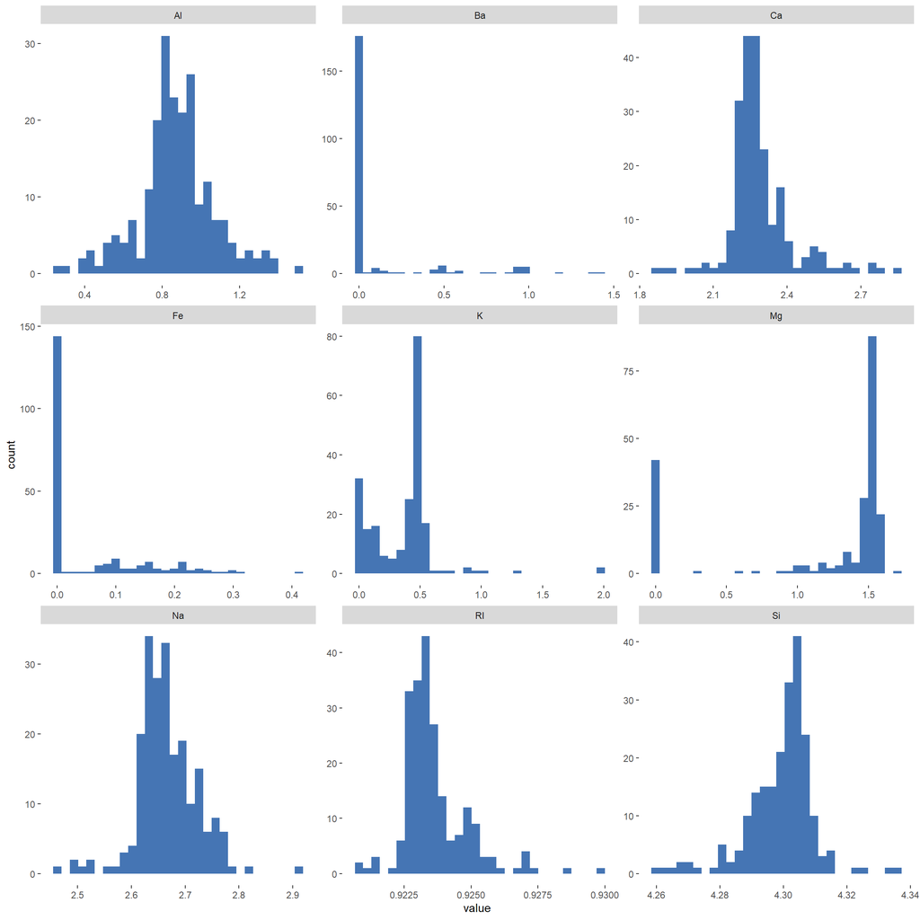

```r
Alt_BoxCox_Glass %>%
  gather() %>%
  ggplot(aes(value)) +
    facet_wrap(~ key, scales = "free") +
    geom_histogram(fill = '#4575b4') +
  theme(panel.background = element_blank(), legend.position="top")
```

I think that in this case it mght be necessary to know if these are real zeroes, or ‘**censored**’ data where the zeroes may actually be trace amounts that are below the detection limit. In this case Kuhn and Johnson state:

> when a sample has a value below the limit of detection, the actual limit can be used in place of the real value. For this situation, it is also common to use a random number between zero and the limit of detection.[^4]

## Exercise 3.2

The soybean data can also be found at the UC Irvine Machine Learning Repository. Data were collected to predict disease in 683 soybeans. The 35 predictors are mostly categorical and include information on the environmental conditions (e.g., temperature, precipitation) and plant conditions (e.g., left spots, mold growth). The outcome labels consist of 19 distinct classes.

The data can be loaded via:

```r
# library(mlbench)
data(Soybean)
## See ?Soybean for details
```

#### (a) Investigate the frequency distributions for the categorical predictors. Are any of the distributions degenerate in the ways discussed earlier in this chapter?

```r
# freq.dist <- apply(Soybean, 2, table)
kable(summary(Soybean[,1:6])) %>%
  kable_styling(bootstrap_options = c("striped", "hover", "condensed"))
```

|  | Class | date | plant.stand | precip | temp | hail |
| --- | --- | --- | --- | --- | --- | --- |
|  | brown-spot : 92 | 5 :149 | 0 :354 | 0 : 74 | 0 : 80 | 0 :435 |
|  | alternarialeaf-spot: 91 | 4 :131 | 1 :293 | 1 :112 | 1 :374 | 1 :127 |
|  | frog-eye-leaf-spot : 91 | 3 :118 | NA’s: 36 | 2 :459 | 2 :199 | NA’s:121 |
|  | phytophthora-rot : 88 | 2 : 93 | NA | NA’s: 38 | NA’s: 30 | NA |
|  | anthracnose : 44 | 6 : 90 | NA | NA | NA | NA |
|  | brown-stem-rot : 44 | (Other):101 | NA | NA | NA | NA |
|  | (Other) :233 | NA’s : 1 | NA | NA | NA | NA |

```r
kable(summary(Soybean[,7:12])) %>%
  kable_styling(bootstrap_options = c("striped", "hover", "condensed"))
```

|  | crop.hist | area.dam | sever | seed.tmt | germ | plant.growth |
| --- | --- | --- | --- | --- | --- | --- |
|  | 0 : 65 | 0 :123 | 0 :195 | 0 :305 | 0 :165 | 0 :441 |
|  | 1 :165 | 1 :227 | 1 :322 | 1 :222 | 1 :213 | 1 :226 |
|  | 2 :219 | 2 :145 | 2 : 45 | 2 : 35 | 2 :193 | NA’s: 16 |
|  | 3 :218 | 3 :187 | NA’s:121 | NA’s:121 | NA’s:112 | NA |
|  | NA’s: 16 | NA’s: 1 | NA | NA | NA | NA |

```r
kable(summary(Soybean[,13:18])) %>%
  kable_styling(bootstrap_options = c("striped", "hover", "condensed"))
```

|  | leaves | leaf.halo | leaf.marg | leaf.size | leaf.shread | leaf.malf |
| --- | --- | --- | --- | --- | --- | --- |
|  | 0: 77 | 0 :221 | 0 :357 | 0 : 51 | 0 :487 | 0 :554 |
|  | 1:606 | 1 : 36 | 1 : 21 | 1 :327 | 1 : 96 | 1 : 45 |
|  | NA | 2 :342 | 2 :221 | 2 :221 | NA’s:100 | NA’s: 84 |
|  | NA | NA’s: 84 | NA’s: 84 | NA’s: 84 | NA | NA |

```r
kable(summary(Soybean[,19:24])) %>%
  kable_styling(bootstrap_options = c("striped", "hover", "condensed"))
```

|  | leaf.mild | stem | lodging | stem.cankers | canker.lesion | fruiting.bodies |
| --- | --- | --- | --- | --- | --- | --- |
|  | 0 :535 | 0 :296 | 0 :520 | 0 :379 | 0 :320 | 0 :473 |
|  | 1 : 20 | 1 :371 | 1 : 42 | 1 : 39 | 1 : 83 | 1 :104 |
|  | 2 : 20 | NA’s: 16 | NA’s:121 | 2 : 36 | 2 :177 | NA’s:106 |
|  | NA’s:108 | NA | NA | 3 :191 | 3 : 65 | NA |
|  | NA | NA | NA | NA’s: 38 | NA’s: 38 | NA |

```r
kable(summary(Soybean[,25:30])) %>%
  kable_styling(bootstrap_options = c("striped", "hover", "condensed"))
```

|  | ext.decay | mycelium | int.discolor | sclerotia | fruit.pods | fruit.spots |
| --- | --- | --- | --- | --- | --- | --- |
|  | 0 :497 | 0 :639 | 0 :581 | 0 :625 | 0 :407 | 0 :345 |
|  | 1 :135 | 1 : 6 | 1 : 44 | 1 : 20 | 1 :130 | 1 : 75 |
|  | 2 : 13 | NA’s: 38 | 2 : 20 | NA’s: 38 | 2 : 14 | 2 : 57 |
|  | NA’s: 38 | NA | NA’s: 38 | NA | 3 : 48 | 4 :100 |
|  | NA | NA | NA | NA | NA’s: 84 | NA’s:106 |

```r
kable(summary(Soybean[,31:36])) %>%
  kable_styling(bootstrap_options = c("striped", "hover", "condensed"))
```

|  | seed | mold.growth | seed.discolor | seed.size | shriveling | roots |
| --- | --- | --- | --- | --- | --- | --- |
|  | 0 :476 | 0 :524 | 0 :513 | 0 :532 | 0 :539 | 0 :551 |
|  | 1 :115 | 1 : 67 | 1 : 64 | 1 : 59 | 1 : 38 | 1 : 86 |
|  | NA’s: 92 | NA’s: 92 | NA’s:106 | NA’s: 92 | NA’s:106 | 2 : 15 |
|  | NA | NA | NA | NA | NA | NA’s: 31 |

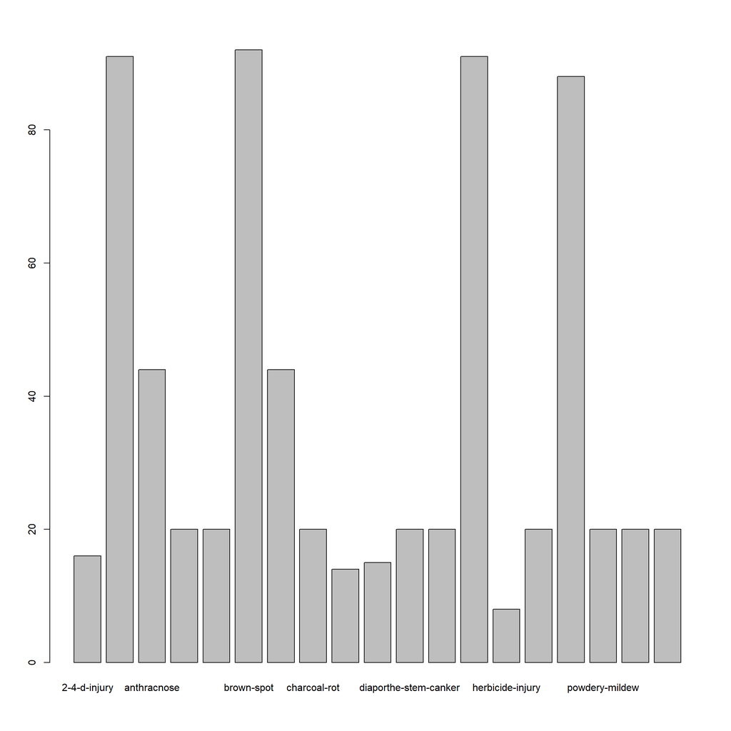

```r
barplot(summary(Soybean$Class))
```

#### (b) Roughly 18 % of the data are missing. Are there particular predictors that are more likely to be missing? Is the pattern of missing data related to the classes?

#### (c) Develop a strategy for handling missing data, either by eliminating predictors or imputation.

## Footnotes

[^1]: http://archive.ics.uci.edu/ml/index.html
[^2]: [Methods to deal with zero values while performing log transformation of variable](https://discuss.analyticsvidhya.com/t/methods-to-deal-with-zero-values-while-performing-log-transformation-of-variable/2431)
[^3]: [Transforming data with zeros](https://robjhyndman.com/hyndsight/transformations/)
[^4]: Kuhn, M., & Johnson, K. (2013). Applied predictive modeling. New York: Springer.